# Polarized Neutron Reflectometry: Channels, Depth Profiles & Simultaneous Fitting

## 4. Loading a polarized experiment and forming the spin asymmetry

A polarized measurement is typically serialized as one data file per spin channel (e.g. `..._uu.dat` for up-up, `..._dd.dat` for down-down). Here we simulate that by writing the truth model's `pp`/`mm` reflectivity, with 1% relative noise, to two files, then loading them back exactly as a user would with real instrument output.

The **spin asymmetry** $SA = (R^{++} - R^{--}) / (R^{++} + R^{--})$ is a common way to look at polarized data directly: it cancels the non-magnetic (nuclear) part of the reflectivity and isolates the magnetic signal, with `Project.spin_asymmetry_for_experiment_at_index()` handling the variance propagation and dropping points where the denominator is too small to be meaningful.

```python
def add_relative_noise(
    reflectivity: np.ndarray, relative_sigma: float, rng: np.random.Generator
) -> tuple[np.ndarray, np.ndarray]:
    """Add reproducible Gaussian noise scaled to a fixed fraction of the signal.

    :param reflectivity: Noise-free reflectivity values.
    :param relative_sigma: Standard deviation as a fraction of the signal (e.g. 0.01 for 1%).
    :param rng: Seeded random number generator, for reproducible tutorial output.
    :return: Noisy reflectivity and the per-point standard deviation (not variance).
    """
    sigma = relative_sigma * np.abs(reflectivity)
    noisy = rng.normal(loc=reflectivity, scale=sigma)
    return np.clip(noisy, 1e-12, None), sigma


Q_DATA = np.linspace(0.01, 0.25, 60)  # a more realistic, instrument-like grid
rng = np.random.default_rng(seed=42)  # fixed seed: this tutorial's output is reproducible

channels_data_grid = truth_model.interface.polarized_reflectivity_profiles(Q_DATA, truth_model.unique_name)
noisy_channels = {
    channel: add_relative_noise(reflectivity, relative_sigma=0.01, rng=rng)
    for channel, reflectivity in channels_data_grid.items()
}

tmp_dir = Path(tempfile.mkdtemp(prefix='easyreflectometry_polarized_'))
pp_path = tmp_dir / 'fe_film_uu.txt'
mm_path = tmp_dir / 'fe_film_dd.txt'
np.savetxt(pp_path, np.column_stack([Q_DATA, noisy_channels['pp'][0], noisy_channels['pp'][1]]))
np.savetxt(mm_path, np.column_stack([Q_DATA, noisy_channels['mm'][0], noisy_channels['mm'][1]]))

# The filename suffixes ('_uu', '_dd') are recognised automatically.
print(project.suggest_polarized_channel_assignment([pp_path, mm_path]))

experiment_index = project.load_polarized_experiment({'pp': pp_path, 'mm': mm_path})
loaded_channels = project.experiment_channels_at_index(experiment_index)
print(f'Loaded polarized experiment at index {experiment_index}, channels: {loaded_channels}')
```

```
{'/tmp/easyreflectometry_polarized_fg06gkfr/fe_film_uu.txt': <PolarizationChannel.PP: 'pp'>, '/tmp/easyreflectometry_polarized_fg06gkfr/fe_film_dd.txt': <PolarizationChannel.MM: 'mm'>}
Loaded polarized experiment at index 0, channels: [<PolarizationChannel.PP: 'pp'>, <PolarizationChannel.MM: 'mm'>]
```

```python
spin_asymmetry = project.spin_asymmetry_for_experiment_at_index(experiment_index)
measured, calculated = spin_asymmetry['measured'], spin_asymmetry['calculated']

plt.figure(figsize=(8, 5))
plt.errorbar(
    measured.x,
    measured.y,
    yerr=np.sqrt(measured.ye),
    fmt='o',
    color='0.3',
    markersize=4,
    alpha=0.6,
    label='Measured (loaded files)',
)
plt.plot(calculated.x, calculated.y, '-r', linewidth=2, label='Calculated (truth model)')
plt.xlabel('Q / Å⁻¹')
plt.ylabel('Spin asymmetry')
plt.title('Spin asymmetry: loaded data vs. the model it was generated from')
plt.legend()
plt.grid(True, alpha=0.3)
plt.show()

print(
    f'{measured.x.size} of {Q_DATA.size} points kept '
    f'({spin_asymmetry["masked_points"]} masked: '
    f'{spin_asymmetry["low_significance_points"]} low-significance, '
    f'{spin_asymmetry["small_denominator_points"]} small-denominator).'
)
```

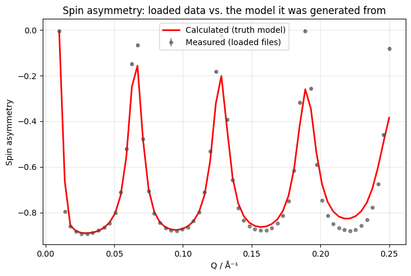

```
60 of 60 points kept (0 masked: 0 low-significance, 0 small-denominator).
```

## 5. Fitting: recovering the moment magnitude from two channels

The most common polarized experiment measures only the two non-spin-flip channels (`pp`, `mm`). If the moment's *direction* is already known from other means (sample geometry, prior characterization), that alone is enough to recover its *magnitude*. This is the standard polarized-fitting case.

`MultiFitter.fit_polarized()` takes a `PolarizedDataSet` and fits every channel it contains **simultaneously against one shared model**: any structural parameter (thickness, roughness, nuclear SLD, scale, background) is constrained jointly by all measured channels, and so is `rho_m`/`theta_m`. Internally `refl1d` still evaluates all cross-sections from a single kernel call, so fitting N channels together costs about as much as fitting one.

We start from a deliberately wrong `rho_m` guess and fit against the two noisy channels loaded above; `theta_m` stays fixed at its (assumed known) true value.

```python
fit_model_2ch, fit_film_2ch = build_magnetic_model(rho_m=1.0, theta_m=THETA_M_TRUE, name='Fit: two channels (rho_m only)')

fit_film_2ch.magnetism.rho_m.fixed = False
fit_film_2ch.magnetism.rho_m.min = 0.0
fit_film_2ch.magnetism.rho_m.max = 5.0
fit_film_2ch.magnetism.theta_m.fixed = True  # moment direction assumed known

initial_channels_2ch = fit_model_2ch.interface.polarized_reflectivity_profiles(Q_PLOT, fit_model_2ch.unique_name)

fit_data_2ch = PolarizedDataSet(
    name='Fe film (pp, mm)',
    channels={
        'pp': DataSet1D(name='pp', x=Q_DATA, y=noisy_channels['pp'][0], ye=noisy_channels['pp'][1] ** 2),
        'mm': DataSet1D(name='mm', x=Q_DATA, y=noisy_channels['mm'][0], ye=noisy_channels['mm'][1] ** 2),
    },
    model=fit_model_2ch,  # PolarizedDataSet.model must be the model the fitter is constructed with
)

fitter_2ch = MultiFitter(fit_model_2ch)
results_2ch = fitter_2ch.fit_polarized(fit_data_2ch)

print(f'Channels fitted: {list(results_2ch.keys())}, all successful: {all(r.success for r in results_2ch.values())}')
print(f'rho_m: {fit_film_2ch.magnetism.rho_m.value:.3f} (started at 1.0, true value {RHO_M_TRUE})')
print(f'Reduced chi^2: {fitter_2ch.reduced_chi:.3f}')

fitted_channels_2ch = fit_model_2ch.interface.polarized_reflectivity_profiles(Q_PLOT, fit_model_2ch.unique_name)
```

[output not shown]

[output not shown]

```
Channels fitted: ['pp', 'mm'], all successful: True
rho_m: 2.501 (started at 1.0, true value 2.5)
Reduced chi^2: 0.803
```

```python
plt.figure(figsize=(8, 5))
plt.errorbar(
    Q_DATA,
    noisy_channels['pp'][0],
    yerr=noisy_channels['pp'][1],
    fmt='o',
    color='0.3',
    markersize=4,
    alpha=0.5,
    label='pp (data)',
)
plt.errorbar(
    Q_DATA,
    noisy_channels['mm'][0],
    yerr=noisy_channels['mm'][1],
    fmt='s',
    color='0.6',
    markersize=4,
    alpha=0.5,
    label='mm (data)',
)
plt.semilogy(Q_PLOT, initial_channels_2ch['pp'], '--k', linewidth=1, alpha=0.6, label='pp (initial guess)')
plt.semilogy(Q_PLOT, initial_channels_2ch['mm'], '--r', linewidth=1, alpha=0.6, label='mm (initial guess)')
plt.semilogy(Q_PLOT, fitted_channels_2ch['pp'], '-k', linewidth=2, label='pp (fitted)')
plt.semilogy(Q_PLOT, fitted_channels_2ch['mm'], '-r', linewidth=2, label='mm (fitted)')
plt.yscale('log')
plt.xlabel('Q / Å⁻¹')
plt.ylabel('Reflectivity')
plt.title('Two-channel fit: rho_m recovered from pp and mm together')
plt.legend(fontsize=8)
plt.grid(True, alpha=0.3)
plt.show()
```

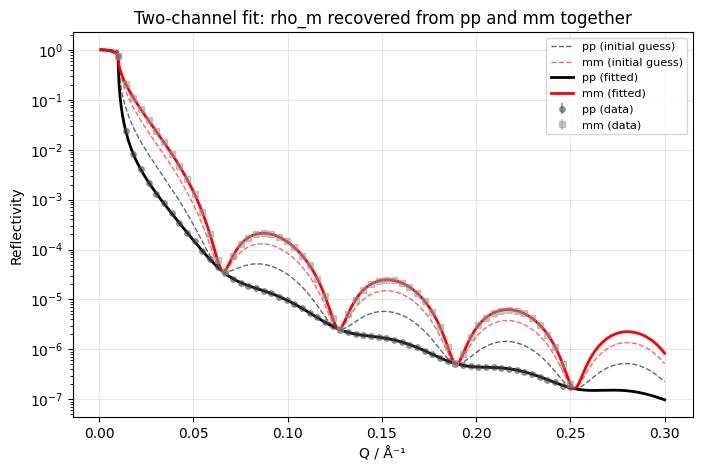

## 6. Fitting: recovering the full magnetization vector from four channels

When the spin-flip channels (`pm`, `mp`) are also measured, `fit_polarized` can determine the moment's *direction* as well as its magnitude. Both `rho_m` and `theta_m` are freed and constrained jointly by all four channels. This is the distinguishing capability of full polarization analysis over a non-spin-flip-only measurement.

We start from wrong guesses for **both** parameters this time.

```python
fit_model_4ch, fit_film_4ch = build_magnetic_model(rho_m=1.5, theta_m=60.0, name='Fit: four channels (rho_m and theta_m)')

fit_film_4ch.magnetism.rho_m.fixed = False
fit_film_4ch.magnetism.rho_m.min = 0.0
fit_film_4ch.magnetism.rho_m.max = 5.0
fit_film_4ch.magnetism.theta_m.fixed = False
fit_film_4ch.magnetism.theta_m.min = 0.0
fit_film_4ch.magnetism.theta_m.max = 90.0

fit_data_4ch = PolarizedDataSet(
    name='Fe film (pp, pm, mp, mm)',
    channels={
        channel: DataSet1D(name=channel, x=Q_DATA, y=values[0], ye=values[1] ** 2) for channel, values in noisy_channels.items()
    },
    model=fit_model_4ch,
)

fitter_4ch = MultiFitter(fit_model_4ch)
results_4ch = fitter_4ch.fit_polarized(fit_data_4ch)

print(f'Channels fitted: {list(results_4ch.keys())}, all successful: {all(r.success for r in results_4ch.values())}')
print(f'rho_m:   {fit_film_4ch.magnetism.rho_m.value:.3f} (started at 1.5, true value {RHO_M_TRUE})')
print(f'theta_m: {fit_film_4ch.magnetism.theta_m.value:.1f}° (started at 60.0°, true value {THETA_M_TRUE}°)')
print(f'Reduced chi^2: {fitter_4ch.reduced_chi:.3f}')
```

[output not shown]

[output not shown]

```
Channels fitted: ['pp', 'pm', 'mp', 'mm'], all successful: True
rho_m:   2.500 (started at 1.5, true value 2.5)
theta_m: 45.0° (started at 60.0°, true value 45.0°)
Reduced chi^2: 0.808
```

## Summary

See `docs/docs/tutorials/simulation/magnetism.ipynb` for the basics of building magnetic samples and selecting a single channel.